# Equating as measurement error model

Chris Haid

April 22, 2014

So let’s try test equating as a measurement error model and let’s get some comparisons with `Stan` and `JAGS`. Let’s assume that a student $i \in N$ has an underlying ability measured on NWEA’s RIT scale $r_i>0 \forall i \in N$. The MAP provides a noisy measure of $r$ that I’ll denote $\hat{r}$, where $r = [r_{1}, r_{2}, \ldots, r_{N}]$ and similarly for $\hat{r}$.

We’ll first sample the $r_i$ from some likely scores and then create a noisy measure of each. Finally we’ll linearly relate the $r_i$ to anther noisy measure $\hat{a} \in [0,1]$.

So first let’s sample $r$ from a known distribution

```r
set.seed(432104)
require(rstan)
N <- 30 # number of students

r<-rnorm(n = N, mean = 211.39, sd =5.83) #8th grade Math NWEA Norm
head(r)
```

```
## [1] 210.4599 224.6591 201.0468 215.6603 203.3875 229.2026
```

Now $\hat{r}$ is noisily measured from $r$:

```r
sigma.r<-1.2
rhat<-rnorm(n=N, mean=r, sd=sigma.r)

head(rhat)
```

```
## [1] 209.5887 225.4890 201.5357 216.4288 204.1839 231.7385
```

And finally we simulate $\hat{a}$ from $r$ as well. In this case I want $a$ to be on the on the $[0,1]$ scale and so I pick $\alpha$ and $\beta$ to normalize the $r$’s on to that scale linearly:

```r
  alpha <- -min(r)/diff(range(r))
  beta <- 1/diff(range(r))

  alpha
```

```
## [1] -5.411656
```

```r
  beta
```

```
## [1] 0.02796169
```

```r
  sigma.a=.01
  ahat <- rnorm(n = N, mean = alpha + beta*r, sd = sigma.a)
  ahat[ahat > 1] <- 1
  ahat[ahat < 0] <- 0

head(ahat)
```

```
## [1] 0.4819412 0.8738586 0.2192464 0.6110404 0.2525802 1.0000000
```

So we our data are the observed $\hat{r}_i$’s and $\hat{a}_i$’s. Our parameters of interest are the $r$, $\alpha$, and $\beta$. I take the standard deviations—$\sigma_{r}$ and $\sigma_a$ to be unknown hyper parameters. So here’s a `Stan` model that should estimate these values:

```r
model.1<-'
  data {
    int<lower=0> N;
    real<lower=0,upper=1> ahat[N];
    real<lower=190, upper=240> rhat[N];
  }
  parameters{
    real alpha;
    real beta;
    real<lower=190, upper=240> r[N];
    real<lower=0> sigma_r;
    real<lower=0> sigma_a;
  }
  model{
    rhat ~ normal(r, sigma_r);
    for (i in 1:N) {
      ahat[i] ~ normal(alpha + beta * r[i], sigma_a) T[0,1];
    }
    alpha ~ normal(0,10);
    beta ~ normal(0,10);
    sigma_r ~ cauchy(0,5);
    sigma_a ~ cauchy(0,5);
  }
'
```

And now for the sampling:

```r
stan.data <- list('ahat' = ahat,
                  'rhat' = rhat,
                  'N' = N)

fit1 <- stan(model_code = model.1,
                   data = stan.data,
                   #pars = c('a','r', 'alpha', 'beta'),
                   chains=2,
                   iter=100)
```

[output not shown]

```r
fit2 <- stan(fit = fit1,
             data = stan.data,
             #pars = c(,'r', 'alpha', 'beta'),
             chains=4,
             iter=10000)
```

[output not shown]

[output cut: 16 more lines]

[output not shown]

```r
fit2
```

```
## Inference for Stan model: model.1.
## 4 chains, each with iter=10000; warmup=5000; thin=1;
## post-warmup draws per chain=5000, total post-warmup draws=20000.
##
##           mean se_mean      sd   2.5%    25%    50%    75%   97.5% n_eff
## alpha    -0.23    0.78   10.59 -24.14  -6.88   0.07   7.08   19.33   185
## beta      2.74    0.18    5.36  -8.13   0.05   1.72   5.22   15.66   904
## r[1]    209.50    0.09    3.59 201.34 208.29 209.58 210.77  217.34  1723
## r[2]    225.16    0.12    3.63 216.50 224.01 225.44 226.56  232.80   956
## r[3]    201.66    0.12    3.56 194.06 200.23 201.52 202.85  210.21   937
## r[4]    216.44    0.12    3.43 208.96 215.15 216.44 217.73  224.05   821
## r[5]    204.20    0.14    3.61 195.91 202.84 204.17 205.52  212.50   703
## r[6]    231.38    0.12    3.38 222.74 230.22 231.66 232.85  238.29   739
## r[7]    222.88    0.13    3.63 215.12 221.51 222.73 224.12  231.66   749
## r[8]    221.66    0.09    3.46 213.42 220.47 221.84 223.01  228.61  1373
## r[9]    223.62    0.12    3.58 214.58 222.46 223.80 224.98  231.20   952
## r[10]   204.77    0.11    3.55 196.87 203.45 204.67 206.06  213.09  1080
## r[11]   194.60    0.14    3.14 190.64 192.88 193.77 195.50  203.04   520
## r[12]   214.24    0.15    3.97 205.45 212.83 214.13 215.50  223.40   729
## r[13]   213.93    0.14    3.66 205.57 212.76 214.05 215.27  221.72   713
## r[14]   211.69    0.19    4.01 202.26 210.44 211.76 213.07  220.10   460
## r[15]   211.74    0.11    3.59 203.33 210.54 211.81 213.12  219.37  1082
## r[16]   204.22    0.15    3.61 195.93 202.87 204.21 205.49  212.44   615
## r[17]   228.69    0.10    3.31 220.82 227.55 228.94 230.09  235.30  1131
## r[18]   210.05    0.16    3.84 201.53 208.86 210.00 211.35  218.51   559
## r[19]   217.97    0.10    3.49 209.82 216.68 218.04 219.26  226.05  1327
## r[20]   204.26    0.20    4.11 196.13 202.76 203.99 205.39  213.62   428
## r[21]   210.08    0.13    3.83 201.99 208.71 209.98 211.19  219.31   907
## r[22]   209.68    0.12    3.62 202.01 208.26 209.57 210.92  217.99   969
## r[23]   212.70    0.10    3.57 204.65 211.39 212.66 213.95  220.93  1343
## r[24]   208.04    0.12    3.72 201.00 206.62 207.85 209.10  216.85   926
## r[25]   210.02    0.12    3.62 201.65 208.73 210.16 211.33  217.76   866
## r[26]   208.49    0.13    3.76 200.20 207.14 208.38 209.71  217.81   806
## r[27]   215.71    0.10    3.52 207.87 214.36 215.70 216.95  224.04  1134
## r[28]   207.57    0.22    3.90 197.32 206.50 207.88 209.03  215.26   323
## r[29]   206.72    0.12    3.64 198.60 205.38 206.67 207.90  215.69   914
## r[30]   205.54    0.13    3.73 196.84 204.26 205.57 206.86  214.24   862
## sigma_r   2.95    0.23    2.34   0.23   1.08   2.34   4.31    8.57   103
## sigma_a 288.59   34.11 2155.73   7.31  28.67  62.56 164.11 1464.78  3994
## lp__     60.86    3.47   30.33  13.69  37.59  56.74  79.58  125.69    77
```

[output cut: 26 more lines]

```
## r[24]   1.00
## r[25]   1.00
## r[26]   1.01
## r[27]   1.00
## r[28]   1.01
## r[29]   1.00
## r[30]   1.01
## sigma_r 1.02
## sigma_a 1.00
## lp__    1.03
##
## Samples were drawn using NUTS(diag_e) at Fri Apr 24 08:40:22 2015.
## For each parameter, n_eff is a crude measure of effective sample size,
## and Rhat is the potential scale reduction factor on split chains (at
## convergence, Rhat=1).
```

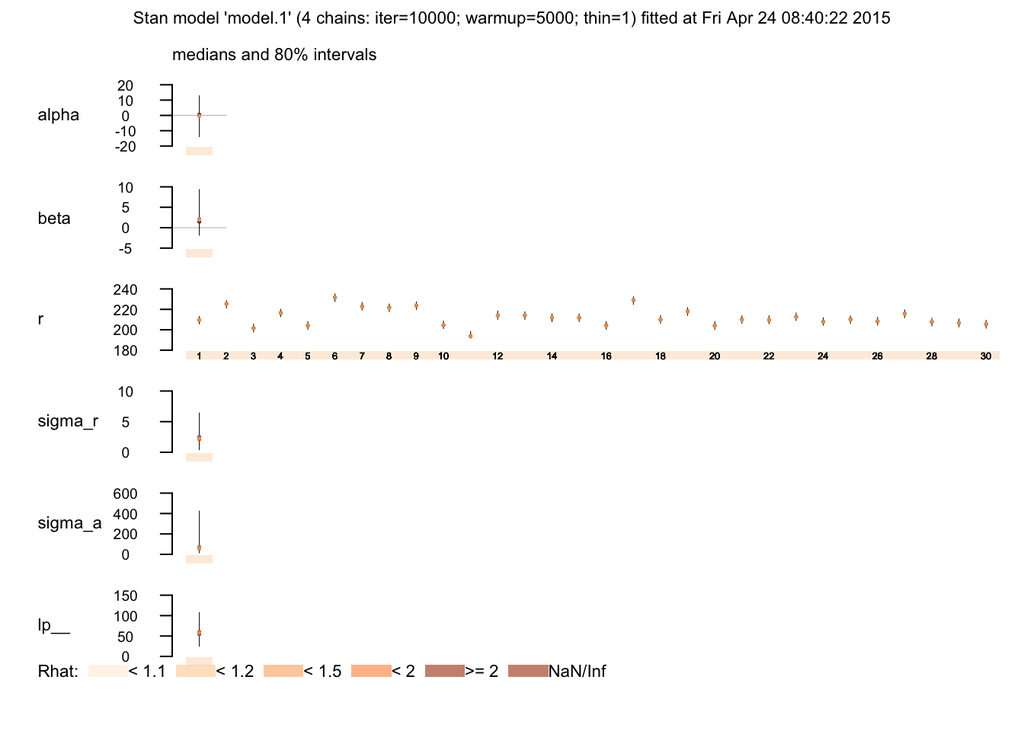

```r
plot(fit2)
```

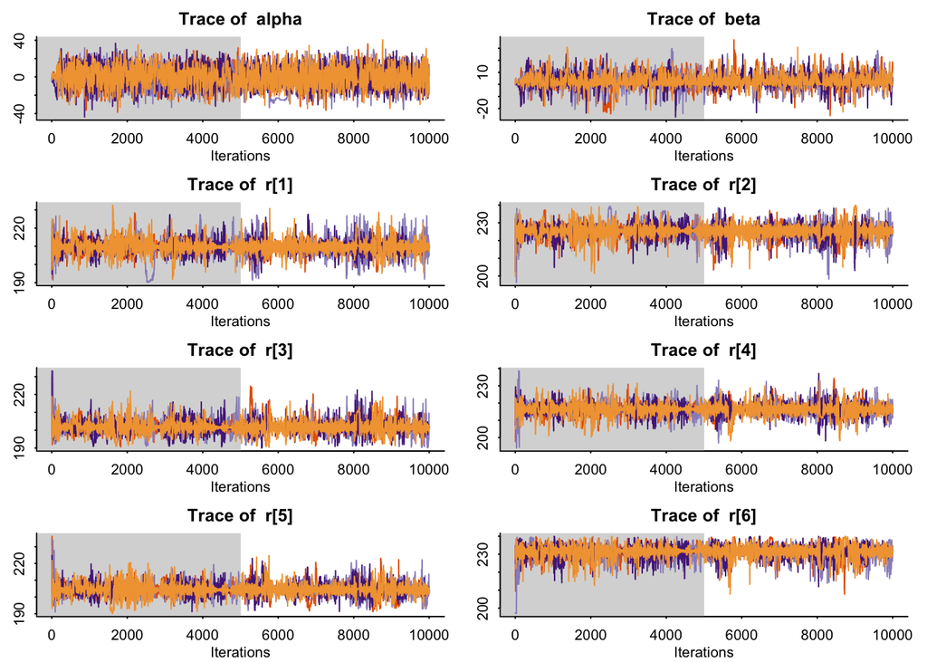

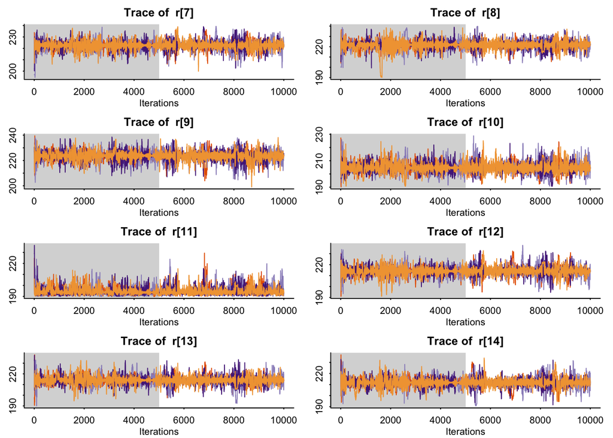

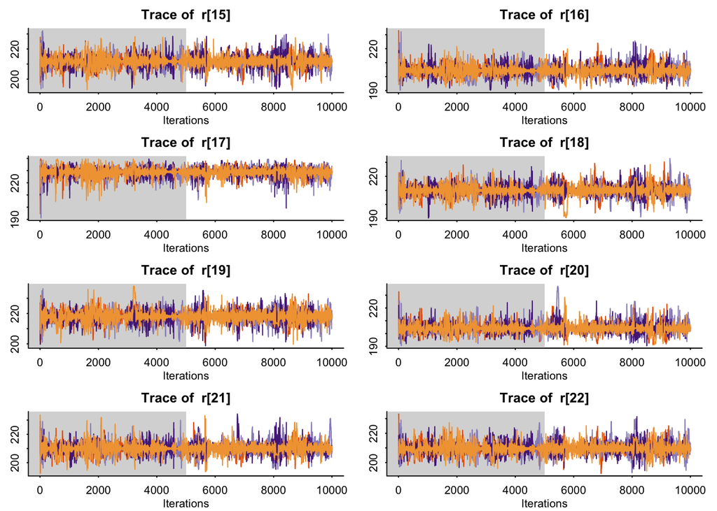

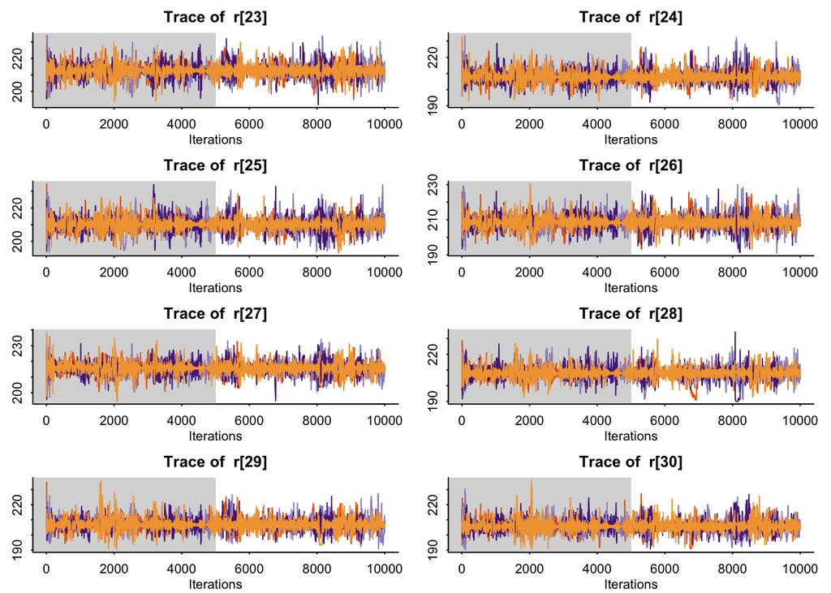

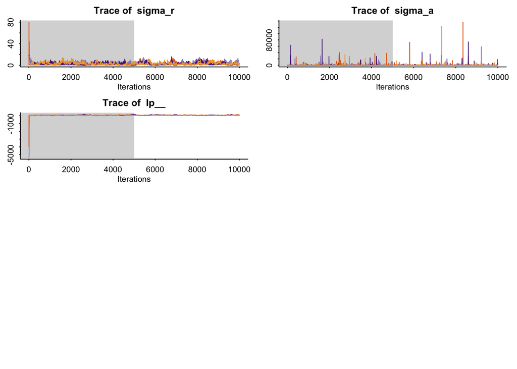

```r
rstan::traceplot(fit2)
```